# breast cancer

Dataset can be found at: https://archive.ics.uci.edu/ml/datasets/Breast+Cancer+Wisconsin+%28Diagnostic%29  
Diagnosis (M = malignant, B = benign)

First we are going to start by visualising data and then apply various models with different hyperparameter tunings to see their effect.

```python
#importing necessary dependencies
import pandas as pd
import numpy as np
import matplotlib.pyplot as plt
```

```python
#reading dataset
dataset = pd.read_csv('./data.csv')
```

```python
dataset.head()
```

|  | id | diagnosis | radius_mean | texture_mean | perimeter_mean | area_mean | smoothness_mean | compactness_mean | concavity_mean | concave points_mean | ... | texture_worst | perimeter_worst | area_worst | smoothness_worst | compactness_worst | concavity_worst | concave points_worst | symmetry_worst | fractal_dimension_worst | Unnamed: 32 |
| --- | --- | --- | --- | --- | --- | --- | --- | --- | --- | --- | --- | --- | --- | --- | --- | --- | --- | --- | --- | --- | --- |
| 0 | 842302 | M | 17.99 | 10.38 | 122.80 | 1001.0 | 0.11840 | 0.27760 | 0.3001 | 0.14710 | ... | 17.33 | 184.60 | 2019.0 | 0.1622 | 0.6656 | 0.7119 | 0.2654 | 0.4601 | 0.11890 | NaN |
| 1 | 842517 | M | 20.57 | 17.77 | 132.90 | 1326.0 | 0.08474 | 0.07864 | 0.0869 | 0.07017 | ... | 23.41 | 158.80 | 1956.0 | 0.1238 | 0.1866 | 0.2416 | 0.1860 | 0.2750 | 0.08902 | NaN |
| 2 | 84300903 | M | 19.69 | 21.25 | 130.00 | 1203.0 | 0.10960 | 0.15990 | 0.1974 | 0.12790 | ... | 25.53 | 152.50 | 1709.0 | 0.1444 | 0.4245 | 0.4504 | 0.2430 | 0.3613 | 0.08758 | NaN |
| 3 | 84348301 | M | 11.42 | 20.38 | 77.58 | 386.1 | 0.14250 | 0.28390 | 0.2414 | 0.10520 | ... | 26.50 | 98.87 | 567.7 | 0.2098 | 0.8663 | 0.6869 | 0.2575 | 0.6638 | 0.17300 | NaN |
| 4 | 84358402 | M | 20.29 | 14.34 | 135.10 | 1297.0 | 0.10030 | 0.13280 | 0.1980 | 0.10430 | ... | 16.67 | 152.20 | 1575.0 | 0.1374 | 0.2050 | 0.4000 | 0.1625 | 0.2364 | 0.07678 | NaN |

5 rows × 33 columns

```python
dataset.describe()
```

|  | id | radius_mean | texture_mean | perimeter_mean | area_mean | smoothness_mean | compactness_mean | concavity_mean | concave points_mean | symmetry_mean | ... | texture_worst | perimeter_worst | area_worst | smoothness_worst | compactness_worst | concavity_worst | concave points_worst | symmetry_worst | fractal_dimension_worst | Unnamed: 32 |
| --- | --- | --- | --- | --- | --- | --- | --- | --- | --- | --- | --- | --- | --- | --- | --- | --- | --- | --- | --- | --- | --- |
| count | 5.690000e+02 | 569.000000 | 569.000000 | 569.000000 | 569.000000 | 569.000000 | 569.000000 | 569.000000 | 569.000000 | 569.000000 | ... | 569.000000 | 569.000000 | 569.000000 | 569.000000 | 569.000000 | 569.000000 | 569.000000 | 569.000000 | 569.000000 | 0.0 |
| mean | 3.037183e+07 | 14.127292 | 19.289649 | 91.969033 | 654.889104 | 0.096360 | 0.104341 | 0.088799 | 0.048919 | 0.181162 | ... | 25.677223 | 107.261213 | 880.583128 | 0.132369 | 0.254265 | 0.272188 | 0.114606 | 0.290076 | 0.083946 | NaN |
| std | 1.250206e+08 | 3.524049 | 4.301036 | 24.298981 | 351.914129 | 0.014064 | 0.052813 | 0.079720 | 0.038803 | 0.027414 | ... | 6.146258 | 33.602542 | 569.356993 | 0.022832 | 0.157336 | 0.208624 | 0.065732 | 0.061867 | 0.018061 | NaN |
| min | 8.670000e+03 | 6.981000 | 9.710000 | 43.790000 | 143.500000 | 0.052630 | 0.019380 | 0.000000 | 0.000000 | 0.106000 | ... | 12.020000 | 50.410000 | 185.200000 | 0.071170 | 0.027290 | 0.000000 | 0.000000 | 0.156500 | 0.055040 | NaN |
| 25% | 8.692180e+05 | 11.700000 | 16.170000 | 75.170000 | 420.300000 | 0.086370 | 0.064920 | 0.029560 | 0.020310 | 0.161900 | ... | 21.080000 | 84.110000 | 515.300000 | 0.116600 | 0.147200 | 0.114500 | 0.064930 | 0.250400 | 0.071460 | NaN |
| 50% | 9.060240e+05 | 13.370000 | 18.840000 | 86.240000 | 551.100000 | 0.095870 | 0.092630 | 0.061540 | 0.033500 | 0.179200 | ... | 25.410000 | 97.660000 | 686.500000 | 0.131300 | 0.211900 | 0.226700 | 0.099930 | 0.282200 | 0.080040 | NaN |
| 75% | 8.813129e+06 | 15.780000 | 21.800000 | 104.100000 | 782.700000 | 0.105300 | 0.130400 | 0.130700 | 0.074000 | 0.195700 | ... | 29.720000 | 125.400000 | 1084.000000 | 0.146000 | 0.339100 | 0.382900 | 0.161400 | 0.317900 | 0.092080 | NaN |
| max | 9.113205e+08 | 28.110000 | 39.280000 | 188.500000 | 2501.000000 | 0.163400 | 0.345400 | 0.426800 | 0.201200 | 0.304000 | ... | 49.540000 | 251.200000 | 4254.000000 | 0.222600 | 1.058000 | 1.252000 | 0.291000 | 0.663800 | 0.207500 | NaN |

8 rows × 32 columns

We find that as of now, id and Unnamed: 32 features are not useful and diagnosis is the label therefore we need to remove id and Unnamed: 32 from our dataset.

```python
y=dataset.diagnosis
list=['id','Unnamed: 32','diagnosis']
x=dataset.drop(list,axis=1)
```

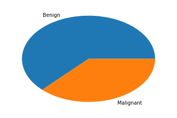

```
B    357
M    212
Name: diagnosis, dtype: int64
```

```python
#Now visualising the distribution of labels in our dataset
v=y.value_counts()
_x=[]
_x.append(v['B'])
_x.append(v['M'])
labels=['Benign','Malignant']
plt.pie(_x,labels=labels)
plt.show()
print(v)
```

```python
#describing columns in our dataset
col=dataset.columns
print(col)
```

```
Index(['id', 'diagnosis', 'radius_mean', 'texture_mean', 'perimeter_mean',
       'area_mean', 'smoothness_mean', 'compactness_mean', 'concavity_mean',
       'concave points_mean', 'symmetry_mean', 'fractal_dimension_mean',
       'radius_se', 'texture_se', 'perimeter_se', 'area_se', 'smoothness_se',
       'compactness_se', 'concavity_se', 'concave points_se', 'symmetry_se',
       'fractal_dimension_se', 'radius_worst', 'texture_worst',
       'perimeter_worst', 'area_worst', 'smoothness_worst',
       'compactness_worst', 'concavity_worst', 'concave points_worst',
       'symmetry_worst', 'fractal_dimension_worst', 'Unnamed: 32'],
      dtype='object')
```

Now we are going to start our process of visualizing our data.  
Before proceeding, we are going to normalize data to reduce difference between different feature values so they can be visualized effectively.

```python
x = (x - x.mean())/(x.std())
```

To startwith, we are going to use violinplot to see distribution of values for benign and malignant tumor for each of the features.

```python
import seaborn as sb
def violin_plot(i,j):
    data = pd.concat([y,x.iloc[:,i:j]],axis=1)
    data = pd.melt(data,id_vars="diagnosis",
                    var_name="features",
                    value_name='value')
    plt.figure(figsize=(10,10))
    sb.violinplot(x="features", y="value", hue="diagnosis", data=data,split=True, inner="quart")
    plt.xticks(rotation=90)
    plt.show()
```

```python
print(len(col))
```

```
33
```

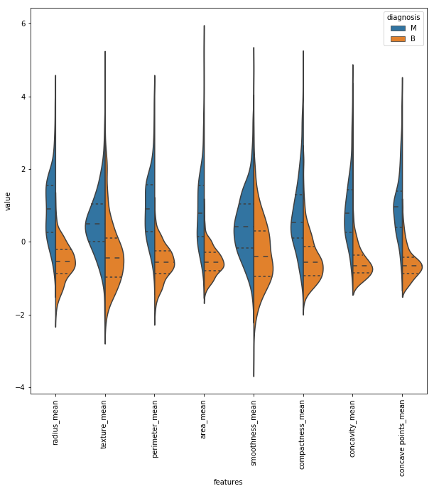

```python
violin_plot(0,8)
```

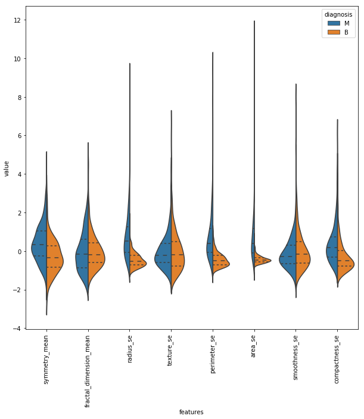

```python
violin_plot(8,16)
```

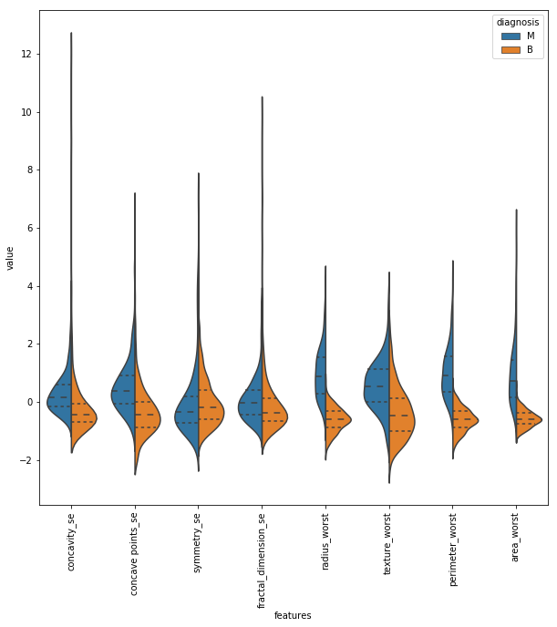

```python
violin_plot(16,24)
```

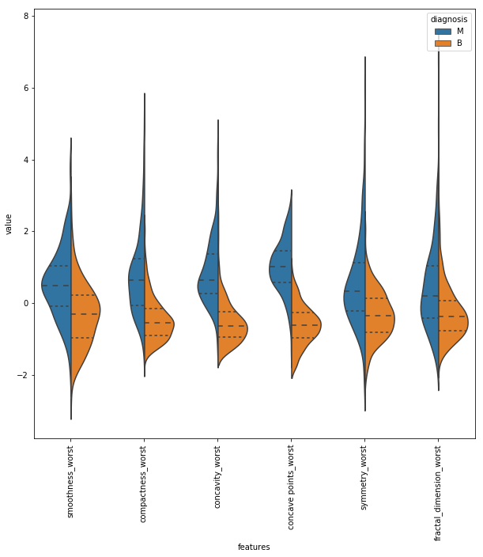

```python
violin_plot(24,33)
```

Above violin plot give us probabilistic disrtibution of values of features corresponding to M & B. Several features show similar distribution and hence may be less useful than others showing clear distinction.

Now we are going to see data distribution using swarm plots

```python
def swarm_plot(i,j):
    data = pd.concat([y,x.iloc[:,i:j]],axis=1)
    data = pd.melt(data,id_vars="diagnosis",
                    var_name="features",
                    value_name='value')
    plt.figure(figsize=(10,10))
    #tic = time.time()
    sb.swarmplot(x="features", y="value", hue="diagnosis", data=data)
    plt.xticks(rotation=90)
    plt.show()
```

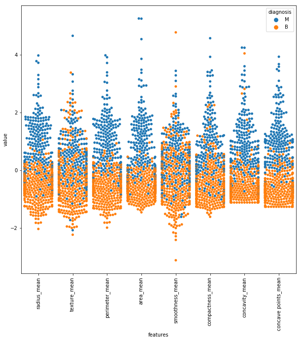

```python
swarm_plot(0,8)
```

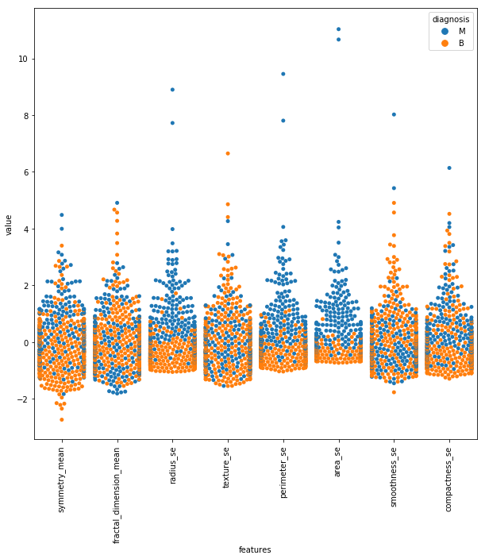

```python
swarm_plot(8,16)
```

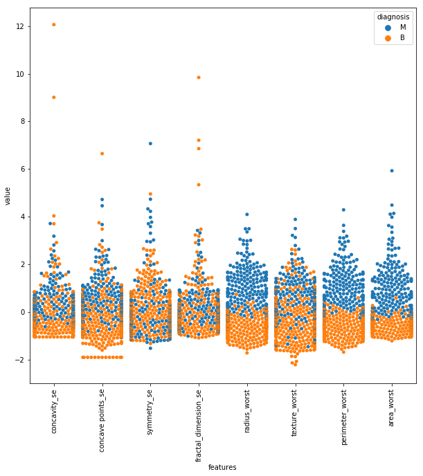

```python
swarm_plot(16,24)
```

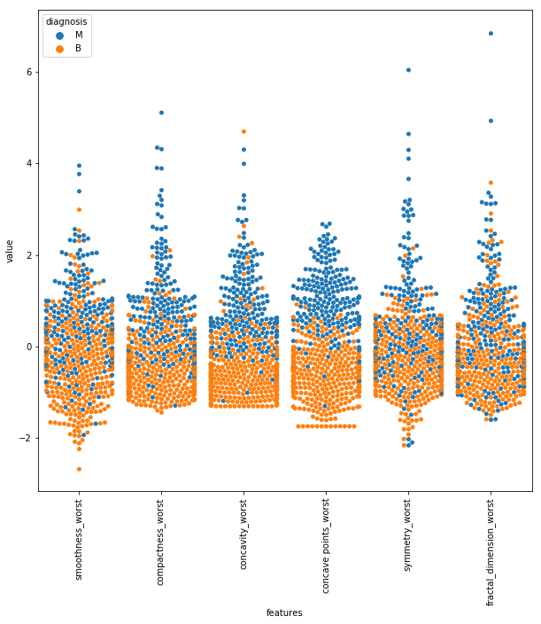

```python
swarm_plot(24,32)
```

Through above swarm plots we can see variance more clearly. Also we are able to figure out which classifiers which features look more clearer in terms of classification.

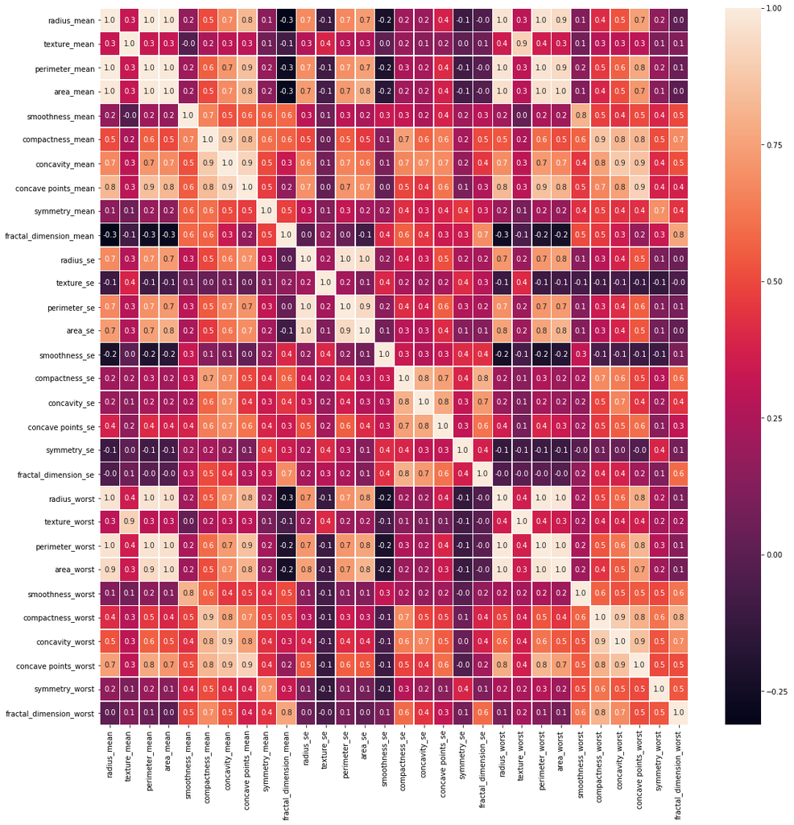

```python
plt.figure(figsize=(18,18))
sb.heatmap(x.corr(),annot=True,linewidth=0.5,fmt='.1f')
plt.show()
```

Above heatmap gives us correlation between all pairs of features.  
We can reduce unwanted features by taking only one feature of pairs having high degree of correlation.

/*-before removing some features let's run random forest classifier over all the features and notice accuracy--*/

```python
#loading dependencies for randomforest classifier
from sklearn.model_selection import train_test_split
from sklearn.ensemble import RandomForestClassifier
from sklearn.metrics import f1_score,confusion_matrix
from sklearn.metrics import accuracy_score
```

```python
# split data train 70 % and test 30 %
x_train, x_test, y_train, y_test = train_test_split(x, y, test_size=0.3, random_state=42)
#random forest classifier with n_estimators=10 (default)
clf_rf = RandomForestClassifier(random_state=43)
print('Now fitting data')
clr_rf = clf_rf.fit(x_train,y_train)
print('data fitting completed')
```

```
Now fitting data
data fitting completed
```

```
Accuracy is:  0.947368421053
```

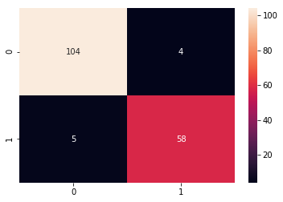

```python
ac = accuracy_score(y_test,clf_rf.predict(x_test))
print('Accuracy is: ',ac)
cm = confusion_matrix(y_test,clf_rf.predict(x_test))
sb.heatmap(cm,annot=True,fmt="d")
plt.show()
```

Now we are going to choose any one of the features in the above list out of correlated features, hence we will make our drop list

```python
drop_list1 = ['perimeter_mean','radius_mean','compactness_mean','concave points_mean','radius_se','perimeter_se',
              'radius_worst','perimeter_worst','compactness_worst','concave points_worst','compactness_se',
              'concave points_se','texture_worst','area_worst']
x_1 = x.drop(drop_list1,axis = 1) #dropping these features
x_1.head()
```

|  | texture_mean | area_mean | smoothness_mean | concavity_mean | symmetry_mean | fractal_dimension_mean | texture_se | area_se | smoothness_se | concavity_se | symmetry_se | fractal_dimension_se | smoothness_worst | concavity_worst | symmetry_worst | fractal_dimension_worst |
| --- | --- | --- | --- | --- | --- | --- | --- | --- | --- | --- | --- | --- | --- | --- | --- | --- |
| 0 | -2.071512 | 0.983510 | 1.567087 | 2.650542 | 2.215566 | 2.253764 | -0.564768 | 2.485391 | -0.213814 | 0.723390 | 1.147747 | 0.906286 | 1.306537 | 2.107672 | 2.748204 | 1.935312 |
| 1 | -0.353322 | 1.907030 | -0.826235 | -0.023825 | 0.001391 | -0.867889 | -0.875473 | 0.741749 | -0.604819 | -0.440393 | -0.804742 | -0.099356 | -0.375282 | -0.146620 | -0.243675 | 0.280943 |
| 2 | 0.455786 | 1.557513 | 0.941382 | 1.362280 | 0.938859 | -0.397658 | -0.779398 | 1.180298 | -0.296744 | 0.212889 | 0.236827 | 0.293301 | 0.526944 | 0.854222 | 1.151242 | 0.201214 |
| 3 | 0.253509 | -0.763792 | 3.280667 | 1.914213 | 2.864862 | 4.906602 | -0.110312 | -0.288125 | 0.689095 | 0.818798 | 4.728520 | 2.045711 | 3.391291 | 1.987839 | 6.040726 | 4.930672 |
| 4 | -1.150804 | 1.824624 | 0.280125 | 1.369806 | -0.009552 | -0.561956 | -0.789549 | 1.189310 | 1.481763 | 0.827742 | -0.360775 | 0.498889 | 0.220362 | 0.612640 | -0.867590 | -0.396751 |

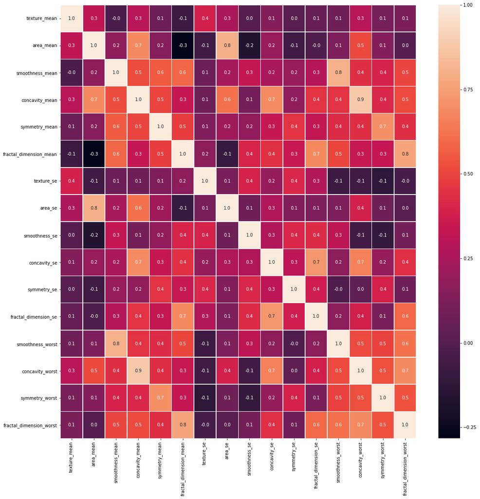

```python
#creating a heatmap to see degree of correlation
plt.figure(figsize=(18,18))
sb.heatmap(x_1.corr(), annot=True, linewidth=0.5, fmt='0.1f')
plt.show()
```

As we can see, degree of correlation have decreased.  
Now we are going to apply our randomforest classifier again on the dataset.

```python
# split data train 70 % and test 30 %
x_train, x_test, y_train, y_test = train_test_split(x_1, y, test_size=0.3, random_state=42)
#random forest classifier with n_estimators=10 (default)
clf_rf = RandomForestClassifier(random_state=43)
print('Now fitting data')
clr_rf = clf_rf.fit(x_train,y_train)
print('data fitting completed')
```

```
Now fitting data
data fitting completed
```

```
Accuracy is:  0.953216374269
```

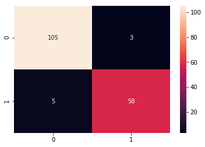

```python
ac = accuracy_score(y_test,clf_rf.predict(x_test))
print('Accuracy is: ',ac)
cm = confusion_matrix(y_test,clf_rf.predict(x_test))
sb.heatmap(cm,annot=True,fmt="d")
plt.show()
```

Accuracy before removing correlated features: Accuracy is: 0.947368421053  
Thus, accuracy has been increased